# Synthetic comparison figures

Andrew Mertens

6/16/2021

## Dataset descriptions

The report compares estimates from 3 synthetic datasets with the raw KI values. The synthetic datasets are labeled:

- QI: Partially synthetic dataset with just quasi-identifiers synthesized
- BC: Partially synthetic dataset with quasi-identifiers and baseline characteristics synthesized, but not child age/anthropometry
- Full: Fully synthesized dataset using updated deep learning model. Each cohort is generated through a model either trained exclusively on that cohort, or on a group of sufficiently similar cohorts, depending on the number of individuals in the cohort.

## Descriptive epidemiology comparisons of Z-scores and age-specific wasting and stunting prevalences/incidences

| syntype | Mean HAZ | Mean WHZ | SD HAZ | SD WHZ |
| --- | --- | --- | --- | --- |
| BC | -1.08 | -0.37 | 1.44 | 1.74 |
| FULL | -1.08 | -0.37 | 1.27 | 1.15 |
| QI | -1.08 | -0.37 | 1.44 | 1.74 |

### Mean Z-scores

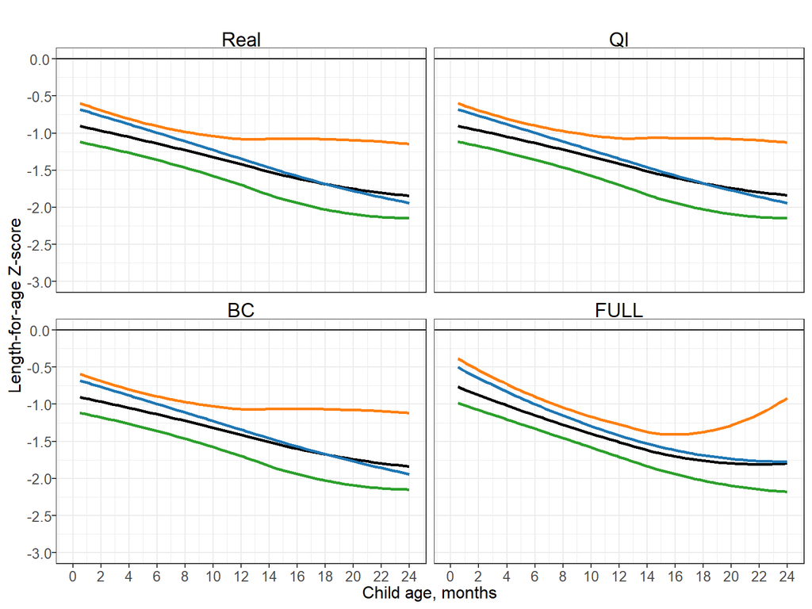

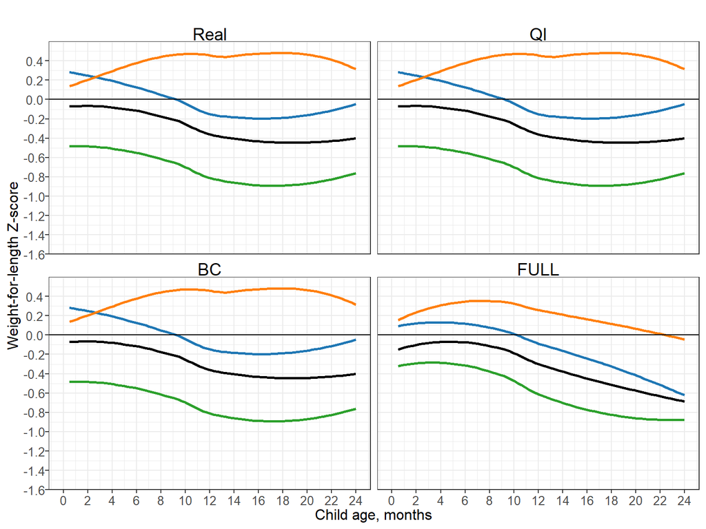

### Stunting prevalence

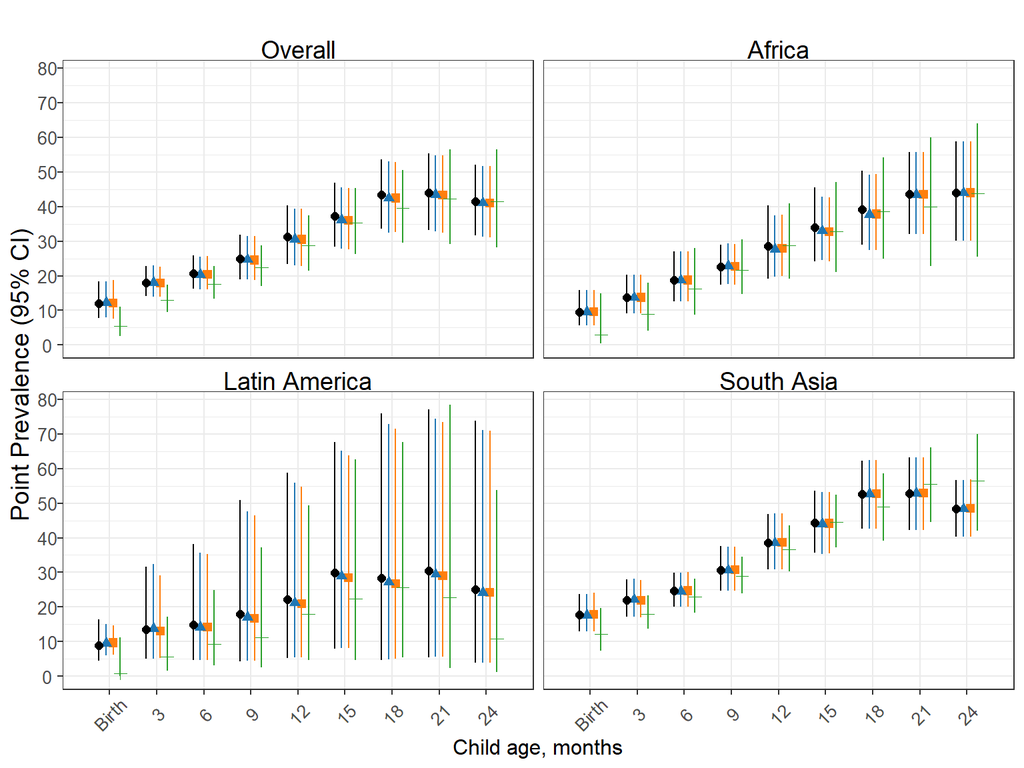

Note slight difference in stunting prevalence between real and QI/BC data. These should match exactly so I’m digging deeper to see if there is a slight different in code (most likely) or an actual difference in the underlying data affecting the prevalence estimates.

### Wasting prevalence

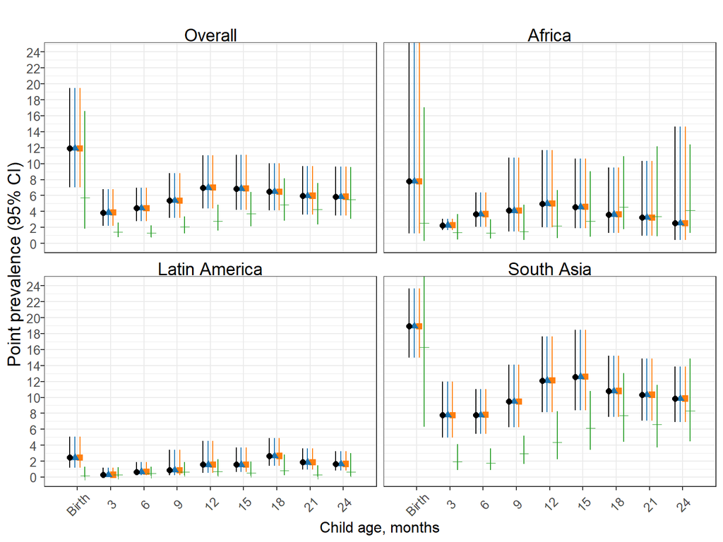

### Severe stunting prevalence

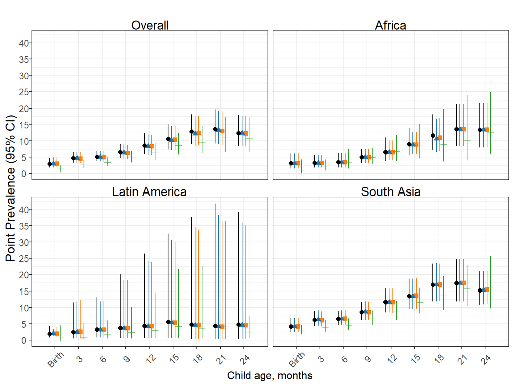

### Severe wasting prevalence

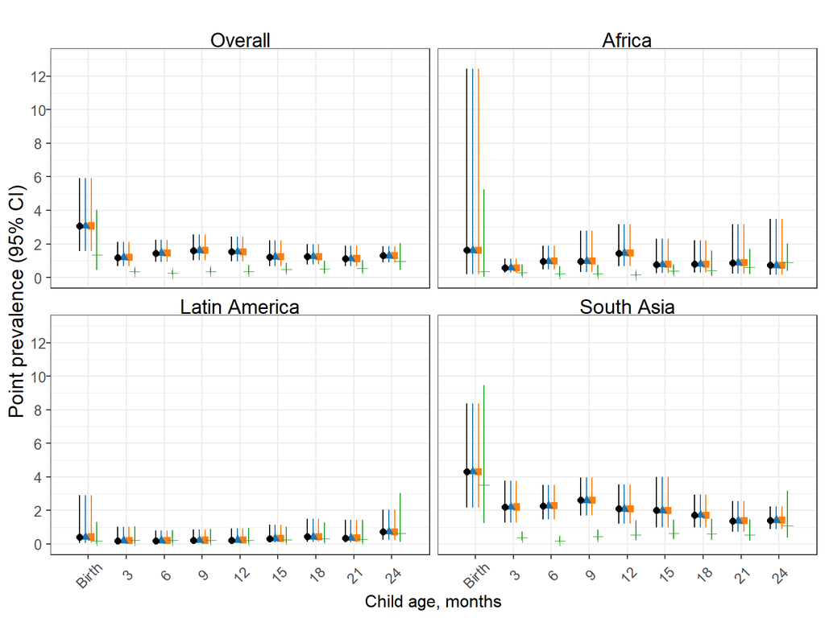

### Stunting cumulative incidence

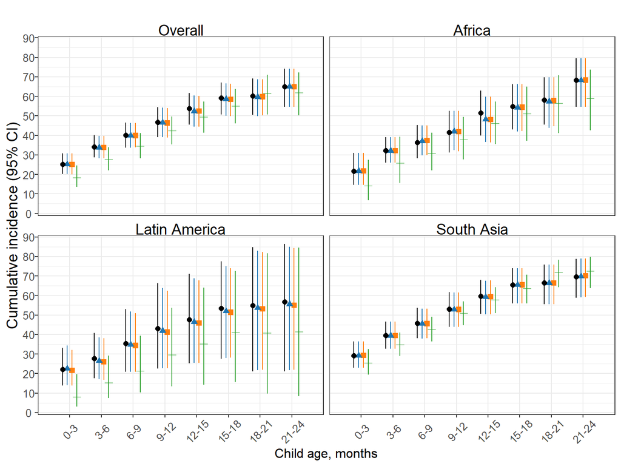

### Wasting cumulative incidence

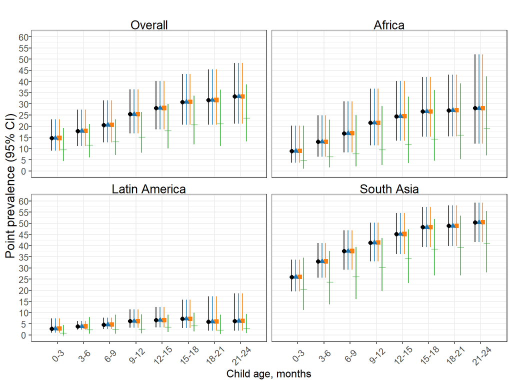

### Example cohort-specific estimates of wasting cumulative incidenc eby age

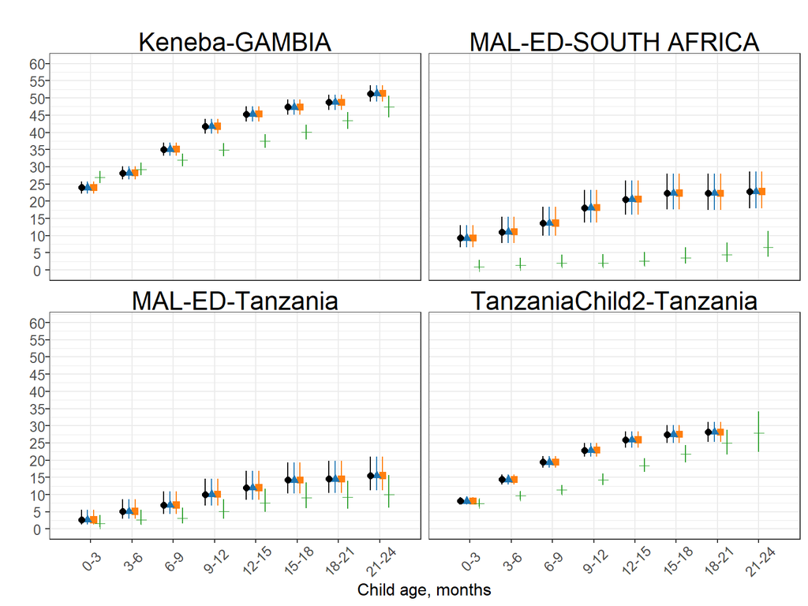

The fully synthesized data matches much more closely in some cohorts than others.

## Covariate-adjusted, SuperLearner-based estimates

Below are comparisons of the most challenging results to replicate with synthetic data: pooled population attributable risks of different baseline covariates on Z-scores at 24 months, estimated using targeted maximum likelihood estimation fit with SuperLearner ensemble machine learning models.

### Comparison of pooled targeted learning estimates

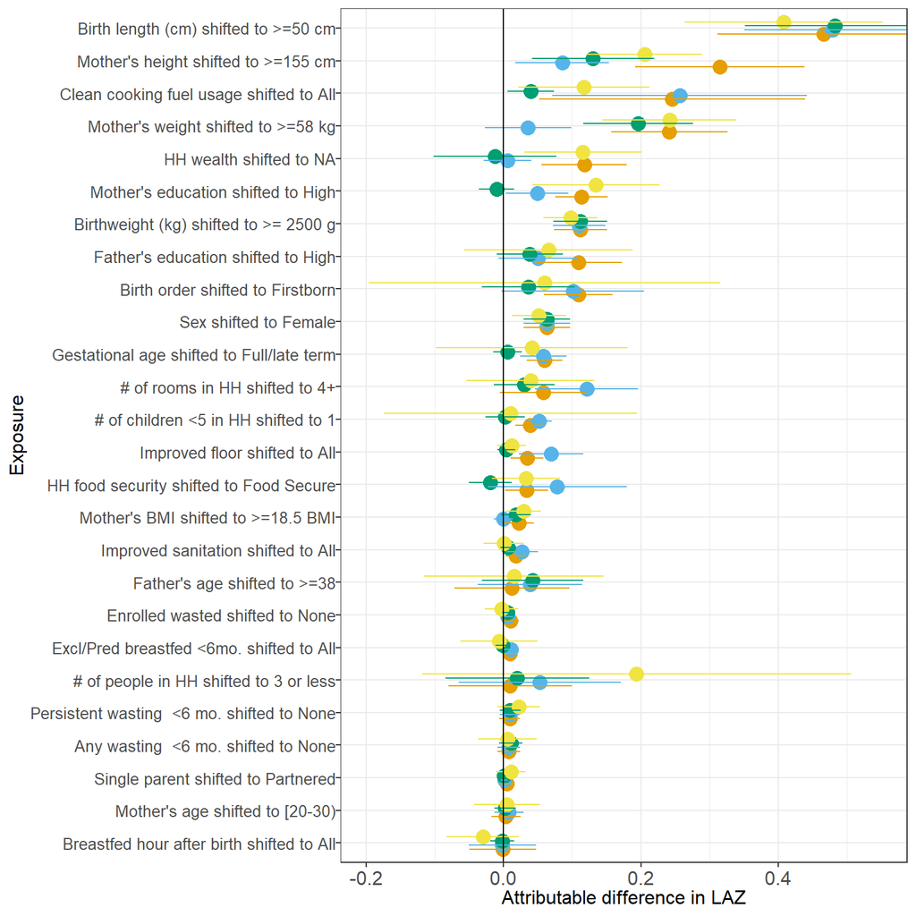

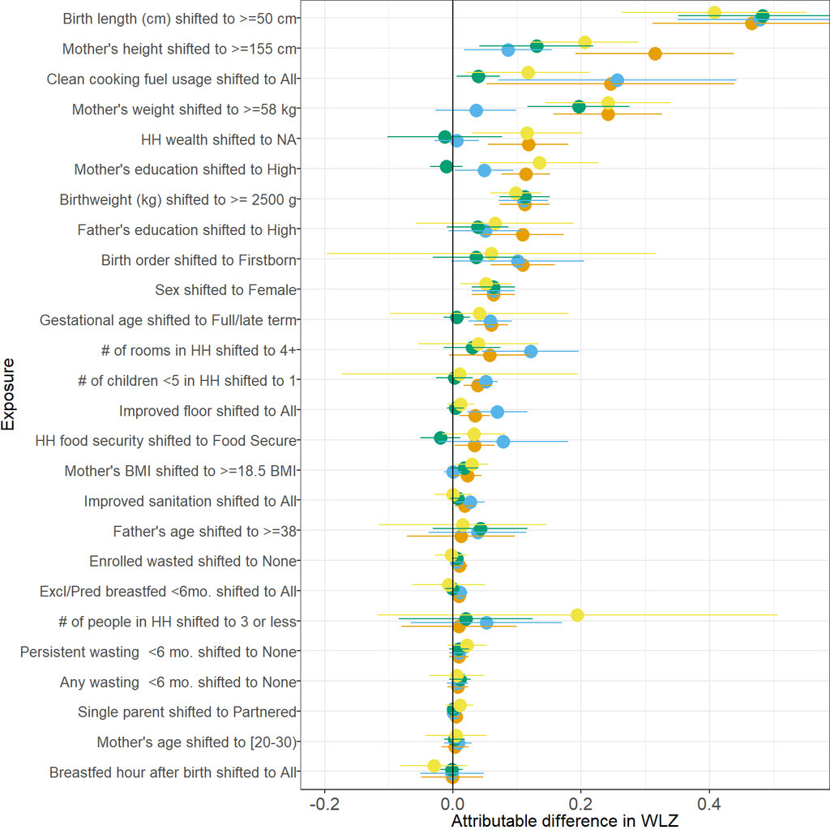

The synthetic data population-attributable risks are generally lower than the real estimates. The fully-synthetic data most closely matches the real-data estimates, but some of the confidence intervals are much higher. We would have made similar inferences for almost all risk factors using the fully synthetic data, but would have concluded that some important risk factors (like maternal weight and education and household wealth are not strongly associated with poor child growth).

### Comparison of difference in cohort-specific targeted learning estimates

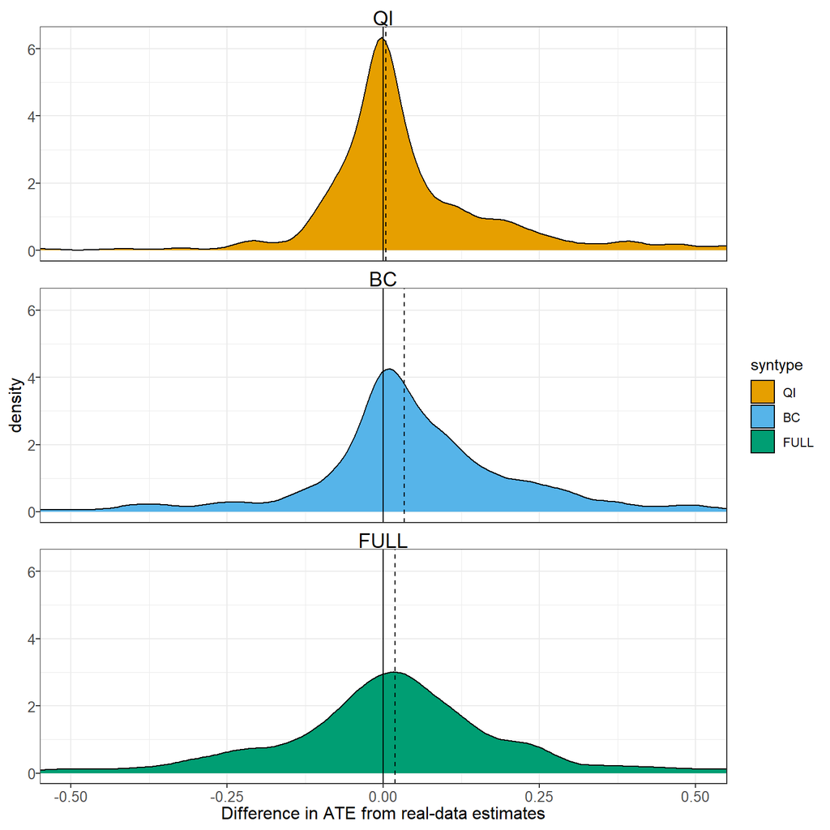

When comparing all cohort-specific average-treatment effects (rather than just pooled population-attribuable risks of Z-scores at 24 months), the QI datasets match the real-data estimates most closely.

## Unadjusted, linear regression estimates

### Comparison of pooled targeted learning estimates

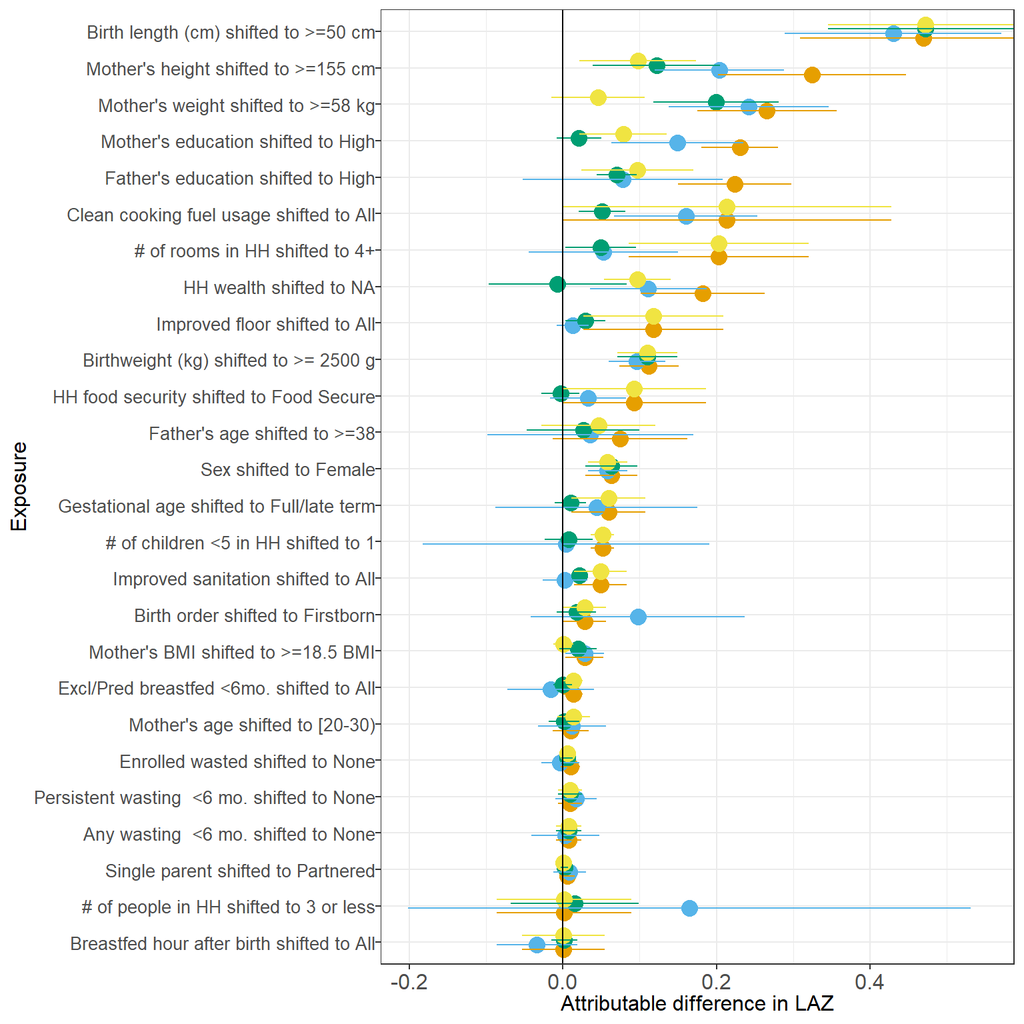

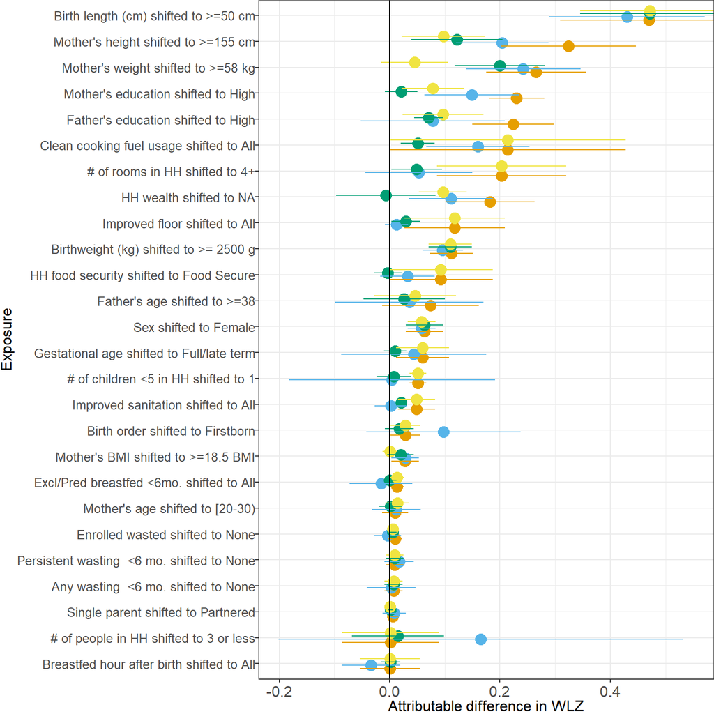

### Comparison of difference in cohort-specific targeted learning estimates

The median difference between the fully synthetic and real data is near-zero, and overall, the bias is smaller from the fully synthetic data compared to the QI/BC data.

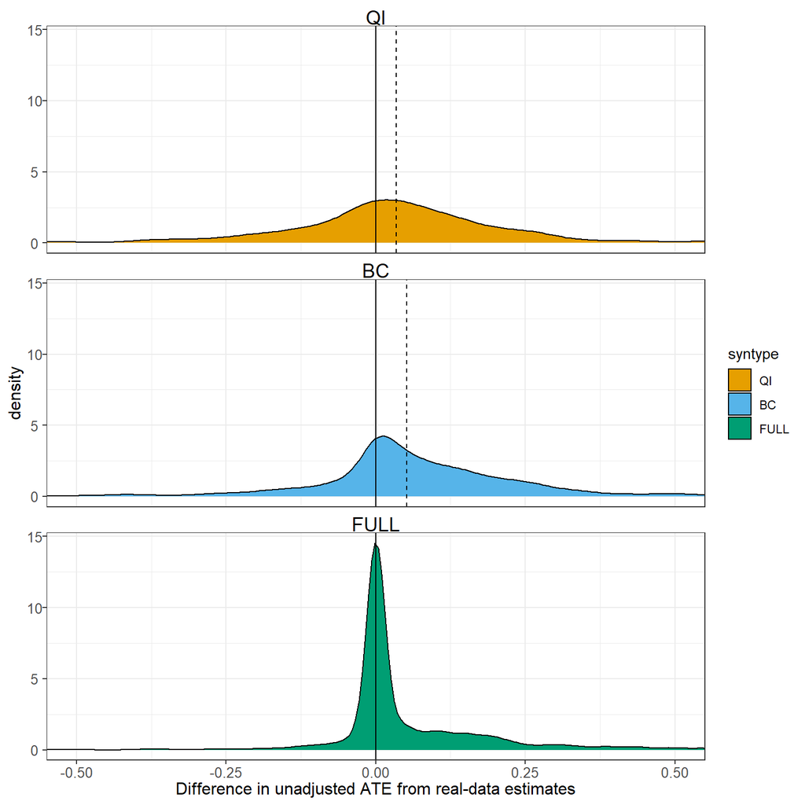